# Lab 2 - Classification and Regression

### 3. Ridge Regression

```
Best parameters set found:
{'alpha': 0.001, 'solver': 'saga'}

Mean score summary of each gridsearch estimator executed
```

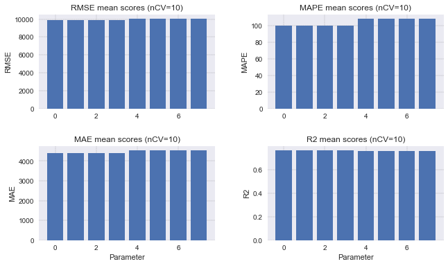

```
10 fold cross validation average scores of the best Estimator found by GridSearchCV

The average MAE for all cv folds is: 			 4415.5
The average MAE percentage (MAPE) for all cv folds is: 	 99.884
The average RMSE for all cv folds is: 			 9918.4
The average R2 for all cv folds is: 			 0.76122
Cross Validation Fold Mean Error Scores
           MAE        MAPE          RMSE        R2
0  4096.625773   98.666957   8574.661956  0.773081
1  4684.829252   99.927366  11071.358648  0.753270
2  3921.177937   98.191623   8407.579079  0.726307
3  4614.470238  109.352725  11067.397575  0.762069
4  4370.386861  105.576334   9505.309126  0.719300
5  4409.048952  100.401707   9487.994477  0.827821
6  4408.958071  101.598722   9504.840896  0.778814
7  4574.509086   89.617090  10223.641235  0.749134
8  4482.802792   97.108893   9675.056534  0.789334
9  4591.695643   98.399030  11666.460309  0.733076
```

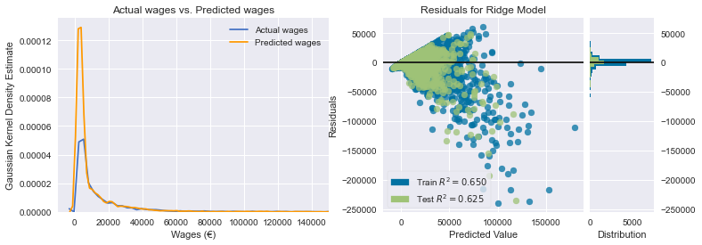

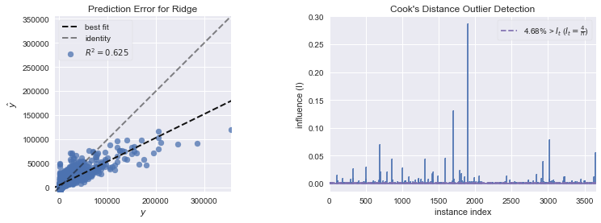

```
Wall time: 9.48 s
```

```python
%%time
from sklearn.linear_model import Ridge

reg = Ridge(fit_intercept=True, normalize=True,copy_X=True
          , max_iter=1000, tol=0.0001, random_state=45)

#Test parameters
alpha = [0.001, 0.1]
solver = [ 'cholesky', 'sparse_cg', 'sag', 'saga']
parameters = {'alpha': alpha, 'solver': solver}

m = evaluate_reg_model_performance('Ridge Reg',parameters,reg,'RMSE',X_reg_train,y_reg_train,X_reg_test,y_reg_test,nCV=10)
model_reg_stats = model_reg_stats.append(m[0])
model_reg_yhat['Ridge Reg'] = m[1].copy()
```

### 4. Elastic Net Regression

```
Best parameters set found:
{'alpha': 0.1, 'l1_ratio': 1, 'selection': 'cyclic', 'warm_start': True}

Mean score summary of each gridsearch estimator executed
```

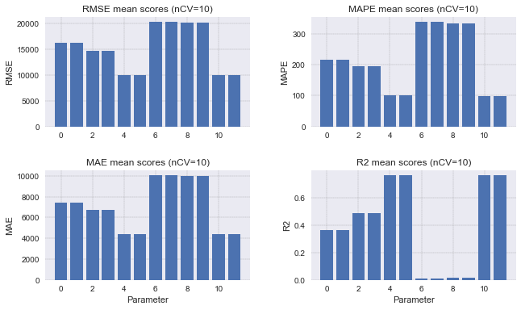

```
10 fold cross validation average scores of the best Estimator found by GridSearchCV

The average MAE for all cv folds is: 			 4385.8
The average MAE percentage (MAPE) for all cv folds is: 	 97.967
The average RMSE for all cv folds is: 			 9916.9
The average R2 for all cv folds is: 			 0.76127
Cross Validation Fold Mean Error Scores
           MAE        MAPE          RMSE        R2
0  4072.485542   97.032897   8581.440151  0.772722
1  4656.643239   97.998602  11063.885963  0.753603
2  3896.549446   96.422252   8417.011093  0.725693
3  4583.224804  107.591592  11065.380608  0.762156
4  4331.169610  103.105043   9490.906427  0.720150
5  4378.801318   98.427827   9478.440533  0.828167
6  4375.039173   99.310920   9506.573769  0.778733
7  4549.558068   88.232205  10227.643063  0.748937
8  4448.591612   94.988311   9668.982907  0.789598
9  4565.855218   96.565313  11668.424758  0.732986
Wall time: 2.45 s
```

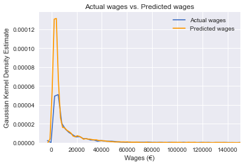

```python
%%time
from sklearn.linear_model import ElasticNet

reg = ElasticNet(fit_intercept=True, normalize=True, precompute=True, copy_X=True
          , max_iter=10000, tol=0.0001, random_state=45)

#Test parameters
l1_ratio = [0.5, 0.75, 1]
alpha = [0.001, 0.1]
selection = ['cyclic','random']
warm_start = [True]
parameters = {'l1_ratio': l1_ratio, 'alpha': alpha, 'selection': selection, 'warm_start': warm_start}

m = evaluate_reg_model_performance('Elastic Net Reg',parameters,reg,'RMSE',X_reg_train,y_reg_train,X_reg_test,y_reg_test,nCV=10)
model_reg_stats = model_reg_stats.append(m[0])
model_reg_yhat['Elastic Net Reg'] = m[1].copy()
```

### 5. Random Forest Regression

```
Wall time: 0 ns
Best parameters set found:
{'max_depth': 15, 'max_features': 'auto', 'max_leaf_nodes': 20, 'min_impurity_decrease': 0, 'min_samples_leaf': 3, 'min_samples_split': 50, 'n_estimators': 350}

Mean score summary of each gridsearch estimator executed
```

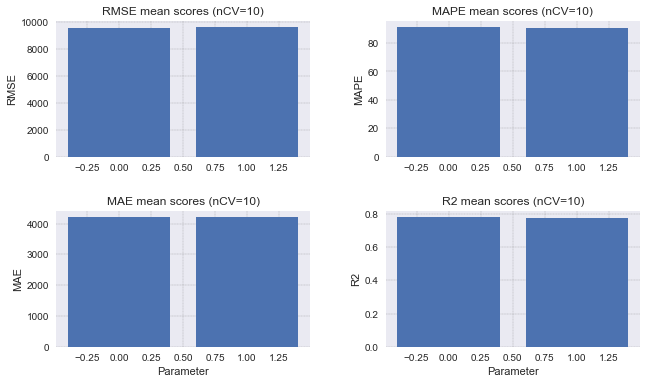

```
10 fold cross validation average scores of the best Estimator found by GridSearchCV

The average MAE for all cv folds is: 			 4194.8
The average MAE percentage (MAPE) for all cv folds is: 	 91.241
The average RMSE for all cv folds is: 			 9527.7
The average R2 for all cv folds is: 			 0.77949
Cross Validation Fold Mean Error Scores
           MAE        MAPE          RMSE        R2
0  3979.721833   96.113929   8427.332377  0.780812
1  4290.748151   86.653841  10661.776151  0.771188
2  3824.485965   92.024138   8128.560202  0.744171
3  4296.591686  102.128857  10013.155768  0.805239
4  4161.970390   96.700344   8932.754647  0.752098
5  4301.957887   87.215541   9472.113517  0.828397
6  4132.668316   91.627415   9270.261554  0.789597
7  4389.670448   82.969937  10268.720749  0.746917
8  4261.061113   90.232720   9385.706784  0.801746
9  4309.457167   86.738582  10716.388632  0.774780
Wall time: 7min 35s
```

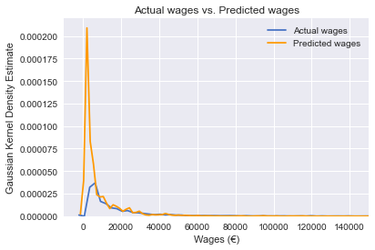

```python
%time
from sklearn.ensemble import RandomForestRegressor

#{'criterion': 'mae',
# 'min_samples_leaf': 25, 'min_samples_split': 2, 'n_estimators': 500, 'n_jobs': 8, 'random_state': 0}

#{'bootstrap': False, 'class_weight': 'balanced', 'max_depth': 40, 'max_features': 'auto',
# 'max_leaf_nodes': 20, 'min_samples_leaf': 3, 'min_samples_split': 10, 'n_estimators': 700}

# 'max_depth' 15,
linreg = RandomForestRegressor()
parameters = {'n_estimators': [ 350], 'max_leaf_nodes': [20],
              'min_impurity_decrease': [0],'max_depth':[15],
              'min_samples_split':[50,100],'min_samples_leaf':[3], 'max_features':['auto']
             }
%time m = evaluate_reg_model_performance('Random Forest',parameters,linreg,'MAE',X_reg_train, y_reg_train, X_reg_test, y_reg_test,numCVs, n_jobs=4)
model_reg_stats = model_reg_stats.append(m[0])
model_reg_yhat['Random Forest'] = m[1].copy()
```

### 6. Extra Trees Regression

```
Best parameters set found:
{'max_depth': 15, 'max_features': 'auto', 'max_leaf_nodes': 20, 'min_impurity_decrease': 0, 'min_samples_leaf': 3, 'min_samples_split': 50, 'n_estimators': 350}

Mean score summary of each gridsearch estimator executed
```

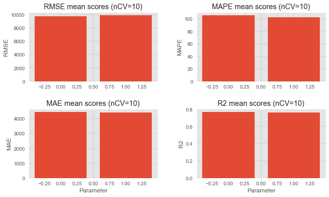

```
10 fold cross validation average scores of the best Estimator found by GridSearchCV

The average MAE for all cv folds is: 			 4435.3
The average MAE percentage (MAPE) for all cv folds is: 	 104.83
The average RMSE for all cv folds is: 			 9801.8
The average R2 for all cv folds is: 			 0.76688
Cross Validation Fold Mean Error Scores
           MAE        MAPE          RMSE        R2
0  4279.338376  113.153683   8497.003788  0.777173
1  4628.330677  101.729759  11314.591135  0.742310
2  3963.919220  104.718114   8174.663853  0.741261
3  4643.430066  113.898686  10511.105869  0.785387
4  4343.455011  107.374414   9484.679901  0.720517
5  4603.173511  101.999541   9726.641990  0.819050
6  4412.392736  106.450463   9704.416864  0.769428
7  4562.435635   96.350880  10187.800818  0.750890
8  4477.349646  102.181707   9784.769848  0.784529
9  4438.910522  100.407201  10632.678071  0.778285
Wall time: 3min 7s
```

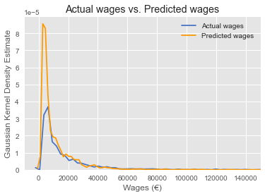

```python
%%time
from sklearn.ensemble import ExtraTreesRegressor

linreg = ExtraTreesRegressor()
parameters = {'n_estimators': [ 350], 'max_leaf_nodes': [20],
              'min_impurity_decrease': [0],'max_depth':[15],
              'min_samples_split':[50,100],'min_samples_leaf':[3], 'max_features':['auto']
             }
m = evaluate_reg_model_performance('ExtraTree',parameters,linreg,'RMSE',X_reg_train,y_reg_train,X_reg_test,y_reg_test,nCV=10, n_jobs=4)
model_reg_stats = model_reg_stats.append(m[0])
model_reg_yhat['ExtraTree'] = m[1].copy()
```

### 7. Multilayer Perceptron Regression

```
Wall time: 0 ns
Best parameters set found:
{'activation': 'logistic', 'alpha': 0.001, 'batch_size': 'auto', 'hidden_layer_sizes': 50, 'learning_rate': 'adaptive', 'learning_rate_init': 0.001, 'max_iter': 2000, 'power_t': 0.5, 'random_state': 0, 'solver': 'sgd'}

Mean score summary of each gridsearch estimator executed
```

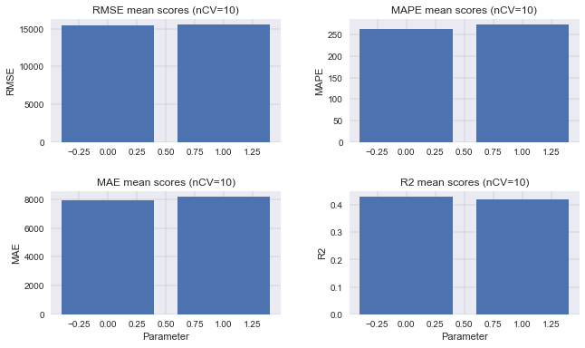

```
10 fold cross validation average scores of the best Estimator found by GridSearchCV

The average MAE for all cv folds is: 			 8022.6
The average MAE percentage (MAPE) for all cv folds is: 	 263.6
The average RMSE for all cv folds is: 			 1.5444e+04
The average R2 for all cv folds is: 			 0.42892
Cross Validation Fold Mean Error Scores
           MAE        MAPE          RMSE        R2
0  7580.945890  263.648011  13473.796680  0.439705
1  8177.818606  265.611052  17180.631902  0.405847
2  7503.419757  277.166095  11777.819068  0.462904
3  8782.204687  296.912099  17661.133893  0.394105
4  7915.794290  276.496693  13814.401748  0.407111
5  8564.251012  251.644695  17645.234762  0.404494
6  7836.178829  259.668557  14842.148013  0.460661
7  8402.351309  275.890734  15328.348289  0.436075
8  7571.047700  230.949491  15035.962982  0.491196
9  7892.444912  237.975524  17678.881882  0.387059
Wall time: 8min 38s
```

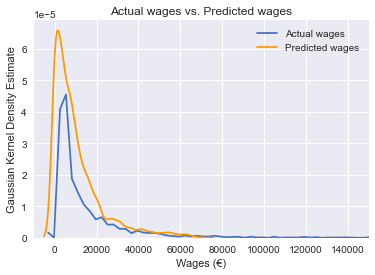

```python
%time
from sklearn.neural_network import MLPRegressor
#{'activation': 'logistic', 'alpha': 0.001, 'batch_size': 'auto', 'hidden_layer_sizes': 200,
# 'learning_rate': 'adaptive',
# 'learning_rate_init': 0.001, 'max_iter': 4000, 'power_t': 0.5, 'random_state': 0, 'solver': 'sgd'}   f
linreg = MLPRegressor()
parameters = { 'activation':['logistic']
              ,'hidden_layer_sizes' : [50]
              ,'solver': ['sgd']
              ,'alpha': [0.001, .0001]
              ,'batch_size':['auto']
              ,'random_state': [0]
              ,'learning_rate': ['adaptive']
              ,'learning_rate_init':[0.001]
              ,'power_t':[0.5]
              ,'max_iter':[2000]
             }
%time m = evaluate_reg_model_performance('MLPerceptron',parameters,linreg,'MAE',X_reg_train, y_reg_train, \
                                         X_reg_test, y_reg_test,numCVs, n_jobs=4)
model_reg_stats = model_reg_stats.append(m[0])
model_reg_yhat['MLPerceptron'] = m[1].copy()
```

### 8. Support Vector Regression

```
Best parameters set found:
{'C': 0.1, 'gamma': 0.02040816326530612, 'kernel': 'linear'}

Mean score summary of each gridsearch estimator executed
```

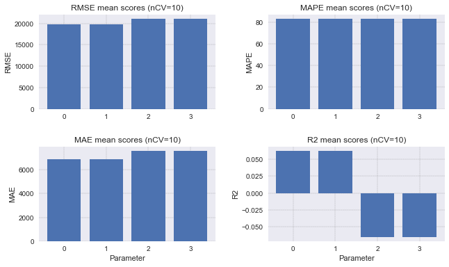

```
10 fold cross validation average scores of the best Estimator found by GridSearchCV

The average MAE for all cv folds is: 			 6882.5
The average MAE percentage (MAPE) for all cv folds is: 	 83.041
The average RMSE for all cv folds is: 			 1.9777e+04
The average R2 for all cv folds is: 			 0.062387
Cross Validation Fold Mean Error Scores
           MAE       MAPE          RMSE        R2
0  6368.811262  85.833284  17228.810453  0.083890
1  6916.250371  82.261844  21584.224950  0.062238
2  6092.091011  83.702122  15434.715575  0.077601
3  7471.952597  86.727318  22100.036084  0.051263
4  6531.601867  82.969409  17313.128122  0.068763
5  7503.668933  82.324757  22238.144381  0.054136
6  6622.778638  84.813048  19512.215484  0.067860
7  7241.782477  79.869899  19851.615781  0.054149
8  7153.967336  81.125241  20540.294446  0.050485
9  6922.081747  80.779230  21968.885524  0.053490
Wall time: 10min 21s
```

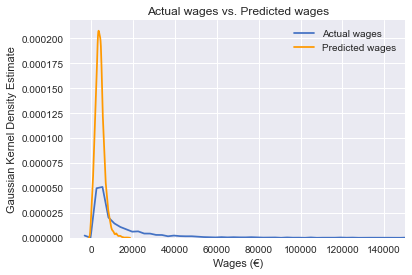

```python
from sklearn.svm import SVR
reg = SVR()
#Set up SVR parameters to test (WARNING: Creates 80 models!!!)
costs = [0.1, .01]
defGamma = 1 / X_reg_test.shape[1]  #This is the default value for the gamma parameter
gammas = [defGamma, 0.01]
kernels = ['linear']
parameters = {'C': costs, 'gamma' : gammas, 'kernel': kernels}
%time m = evaluate_reg_model_performance('SVR',parameters,reg,'MAE',X_reg_train, y_reg_train, \
                                         X_reg_test, y_reg_test,numCVs, n_jobs=4)
model_reg_stats = model_reg_stats.append(m[0])
model_reg_yhat['SVR'] = m[1].copy()
```

### 9. Linear Regression_LDA

```
Best parameters set found:
{'fit_intercept': True, 'normalize': True}

Mean score summary of each gridsearch estimator executed
```

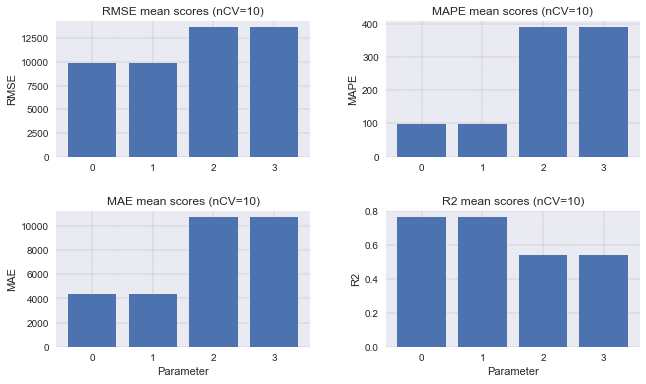

```
10 fold cross validation average scores of the best Estimator found by GridSearchCV

The average MAE for all cv folds is: 			 4376.2
The average MAE percentage (MAPE) for all cv folds is: 	 99.091
The average RMSE for all cv folds is: 			 9894.1
The average R2 for all cv folds is: 			 0.76239
Cross Validation Fold Mean Error Scores
           MAE        MAPE          RMSE        R2
0  4053.969560   98.518046   8563.005632  0.773697
1  4609.954016   97.551310  10989.919596  0.756887
2  3894.518703   98.567887   8414.627663  0.725848
3  4587.982742  108.556695  11089.113429  0.761134
4  4318.860469  103.900232   9439.077323  0.723199
5  4347.251801   97.783292   9447.690892  0.829281
6  4371.568605  101.139886   9459.640664  0.780913
7  4535.174942   89.478555  10190.114941  0.750776
8  4475.999138   97.316740   9695.063103  0.788461
9  4566.342309   98.100762  11652.466224  0.733716
```

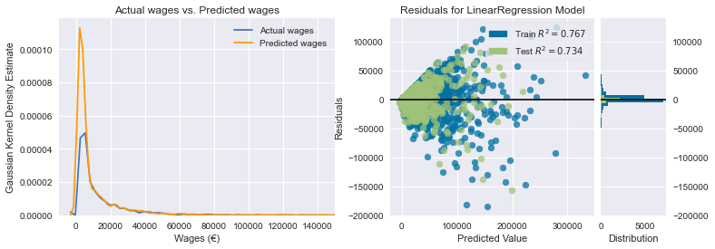

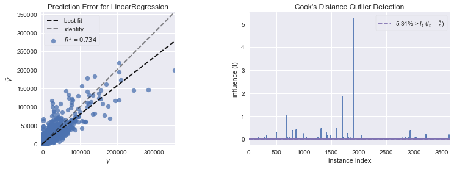

```
Wall time: 6.78 s
```

```python
%%time
import warnings
warnings.filterwarnings("ignore")
from sklearn.linear_model import LinearRegression

linreg = LinearRegression()
parameters = {'normalize':(True,False), 'fit_intercept':(True,False)}

m = evaluate_reg_model_performance('Linear Reg_LDA',parameters,linreg,'RMSE',X_lda_train,y_reg_train,X_lda_test,y_reg_test,nCV=10)
model_reg_stats = model_reg_stats.append(m[0])
model_reg_yhat['Linear Reg_LDA'] = m[1].copy()
```

### 10. LASSO Regression_LDA

```
Best parameters set found:
{'alpha': 0.1, 'selection': 'random', 'warm_start': True}

Mean score summary of each gridsearch estimator executed
```

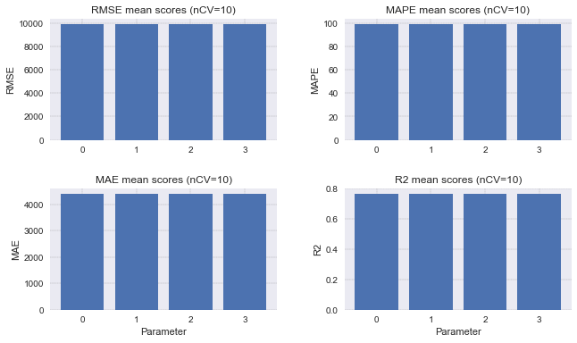

```
10 fold cross validation average scores of the best Estimator found by GridSearchCV

The average MAE for all cv folds is: 			 4376.9
The average MAE percentage (MAPE) for all cv folds is: 	 99.193
The average RMSE for all cv folds is: 			 9893.9
The average R2 for all cv folds is: 			 0.76242
Cross Validation Fold Mean Error Scores
           MAE        MAPE          RMSE        R2
0  4054.015754   98.599519   8558.028784  0.773960
1  4610.414248   97.643418  10988.039422  0.756970
2  3895.051473   98.668430   8411.643729  0.726042
3  4589.727242  108.673604  11093.628125  0.760940
4  4319.269704  104.005413   9437.309836  0.723302
5  4348.907085   97.895856   9449.210076  0.829226
6  4371.996894  101.241975   9460.359738  0.780879
7  4535.221735   89.550594  10187.504052  0.750904
8  4477.050526   97.433224   9697.244535  0.788366
9  4567.457405   98.218595  11655.660874  0.733570
```

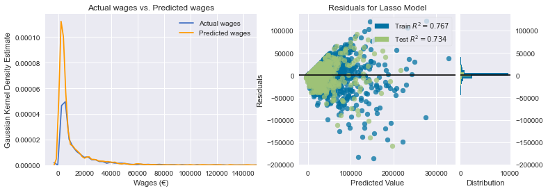

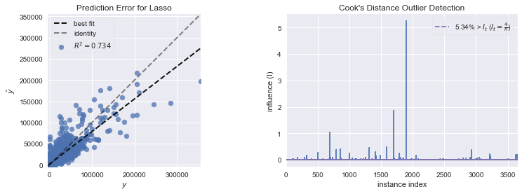

```
Wall time: 5.29 s
```

```python
%%time
from sklearn.linear_model import Lasso

reg = Lasso(fit_intercept=True, normalize=True,copy_X=True, max_iter=10000, precompute=True, tol=0.0001, random_state=45)

#Test parameters
alpha = [0.001, 0.1]
selection = ['cyclic','random']
warm_start = [True]
parameters = {'alpha': alpha, 'selection': selection, 'warm_start': warm_start}

m = evaluate_reg_model_performance('Lasso Reg_LDA',parameters,reg,'RMSE',X_lda_train,y_reg_train,X_lda_test,y_reg_test,nCV=10)
model_reg_stats = model_reg_stats.append(m[0])
model_reg_yhat['Lasso Reg_LDA'] = m[1].copy()
```

### 11. Ridge Regression_LDA

```
Best parameters set found:
{'alpha': 0.001, 'solver': 'saga'}

Mean score summary of each gridsearch estimator executed
```

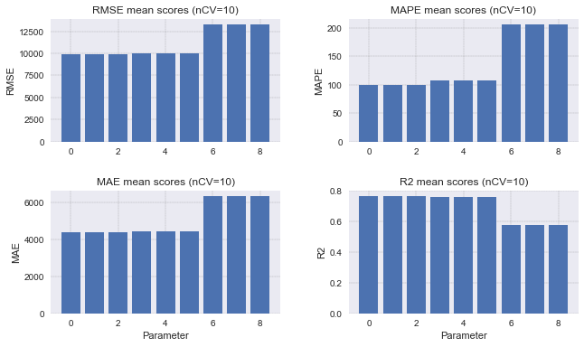

```
10 fold cross validation average scores of the best Estimator found by GridSearchCV

The average MAE for all cv folds is: 			 4375.7
The average MAE percentage (MAPE) for all cv folds is: 	 99.125
The average RMSE for all cv folds is: 			 9893.7
The average R2 for all cv folds is: 			 0.76243
Cross Validation Fold Mean Error Scores
           MAE        MAPE          RMSE        R2
0  4053.208007   98.573965   8557.189462  0.774005
1  4609.115600   97.600251  10986.855614  0.757022
2  3893.927583   98.605199   8410.783751  0.726098
3  4588.414464  108.568106  11093.555467  0.760943
4  4317.468728  103.913834   9436.761735  0.723334
5  4348.117169   97.826638   9449.997031  0.829197
6  4370.790512  101.180550   9460.382069  0.780878
7  4534.675531   89.515063  10187.521738  0.750903
8  4475.755975   97.341887   9697.492964  0.788355
9  4565.787047   98.119731  11656.103227  0.733550
```

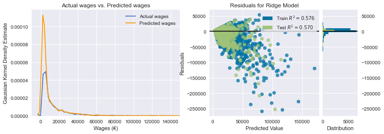

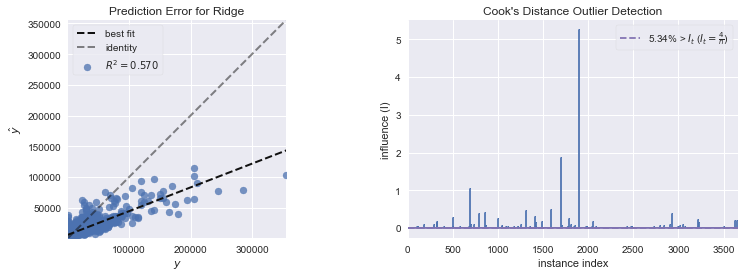

```
Wall time: 5.75 s
```

```python
%%time
from sklearn.linear_model import Ridge

reg = Ridge(fit_intercept=True, normalize=True,copy_X=True
          , max_iter=1000, tol=0.0001, random_state=45)

#Test parameters
alpha = [0.001, 0.1, 1]
solver = ['cholesky','sparse_cg', 'saga']
parameters = {'alpha': alpha, 'solver': solver}

m = evaluate_reg_model_performance('Ridge Reg_LDA',parameters,reg,'RMSE',X_lda_train,y_reg_train,X_lda_test,y_reg_test,nCV=10)
model_reg_stats = model_reg_stats.append(m[0])
model_reg_yhat['Ridge Reg_LDA'] = m[1].copy()
```

### 12. Elastic Net Regression_LDA

```
Best parameters set found:
{'alpha': 1, 'l1_ratio': 1, 'selection': 'random', 'warm_start': True}

Mean score summary of each gridsearch estimator executed
```

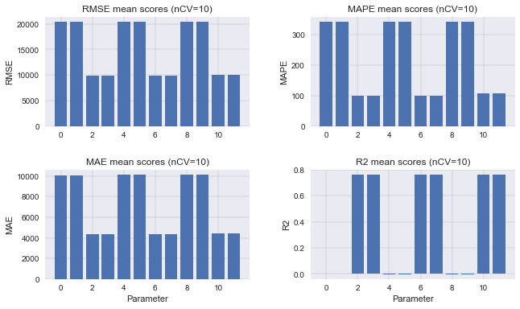

```
10 fold cross validation average scores of the best Estimator found by GridSearchCV

The average MAE for all cv folds is: 			 4384.6
The average MAE percentage (MAPE) for all cv folds is: 	 100.18
The average RMSE for all cv folds is: 			 9893.1
The average R2 for all cv folds is: 			 0.76258
Cross Validation Fold Mean Error Scores
           MAE        MAPE          RMSE        R2
0  4056.229884   99.445524   8514.677673  0.776245
1  4615.050727   98.501527  10972.735014  0.757646
2  3901.074882   99.655384   8385.832735  0.727721
3  4605.812482  109.757897  11134.905350  0.759158
4  4323.355784  104.973824   9422.360898  0.724178
5  4364.148217   98.936849   9464.573925  0.828670
6  4376.521754  102.259447   9468.409097  0.780506
7  4537.160914   90.297702  10164.814627  0.752013
8  4487.843550   98.586647   9717.724822  0.787471
9  4579.102122   99.380975  11684.869893  0.732233
Wall time: 1.01 s
```

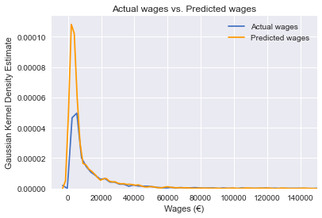

```python
%%time
from sklearn.linear_model import ElasticNet

reg = ElasticNet(fit_intercept=True, normalize=True, precompute=True, copy_X=True
          , max_iter=10000, tol=0.0001, random_state=45)

#Test parameters
l1_ratio = [ 0.75, 1]
alpha = [0.1, 1, 10]
selection = ['cyclic','random']
warm_start = [True]
parameters = {'l1_ratio': l1_ratio, 'alpha': alpha, 'selection': selection, 'warm_start': warm_start}

m = evaluate_reg_model_performance('Elastic Net Reg_LDA',parameters,reg,'RMSE',X_lda_train,y_reg_train,X_lda_test,y_reg_test,nCV=10)
model_reg_stats = model_reg_stats.append(m[0])
model_reg_yhat['Elastic Net Reg_LDA'] = m[1].copy()
```

### 13. Random Forest Regression_LDA

```
Best parameters set found:
{'max_depth': 15, 'max_features': 'auto', 'max_leaf_nodes': 20, 'min_impurity_decrease': 0, 'min_samples_leaf': 3, 'min_samples_split': 50, 'n_estimators': 350}

Mean score summary of each gridsearch estimator executed
```

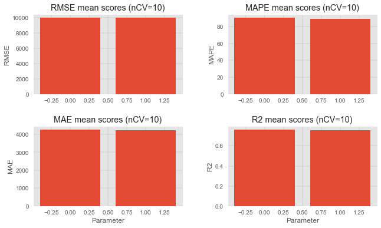

```
10 fold cross validation average scores of the best Estimator found by GridSearchCV

The average MAE for all cv folds is: 			 4249.4
The average MAE percentage (MAPE) for all cv folds is: 	 90.269
The average RMSE for all cv folds is: 			 9949.6
The average R2 for all cv folds is: 			 0.75936
Cross Validation Fold Mean Error Scores
           MAE        MAPE          RMSE        R2
0  4047.835574   93.820252   9074.662891  0.745845
1  4448.923534   87.285428  11252.889460  0.745113
2  3727.129224   89.928613   7980.570898  0.753402
3  4430.257643  101.732138  10783.537538  0.774118
4  4229.923502   94.768089   9740.416973  0.705243
5  4244.090169   87.733651   9489.449335  0.827768
6  4140.292514   90.269896   9144.778952  0.795254
7  4533.070927   82.639745  10819.031672  0.719064
8  4246.877235   88.516463   9462.381357  0.798493
9  4445.374213   85.998090  11747.872841  0.729338
Wall time: 1min 18s
```

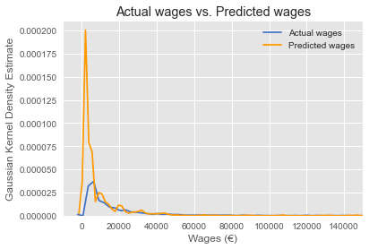

```python
%%time
from sklearn.ensemble import RandomForestRegressor

reg = RandomForestRegressor()

parameters = {'n_estimators': [ 350], 'max_leaf_nodes': [20],
              'min_impurity_decrease': [0],'max_depth':[15],
              'min_samples_split':[50,100],'min_samples_leaf':[3], 'max_features':['auto']
             }
m = evaluate_reg_model_performance('Random Forest_LDA',parameters,reg,'RMSE',X_lda_train,y_reg_train,X_lda_test,y_reg_test,nCV=10, n_jobs=4)
model_reg_stats = model_reg_stats.append(m[0])
model_reg_yhat['Random Forest_LDA'] = m[1].copy()
```

### 14. Extra Trees Regression_LDA

```
Best parameters set found:
{'max_depth': 15, 'max_features': 'auto', 'max_leaf_nodes': 20, 'min_impurity_decrease': 0, 'min_samples_leaf': 3, 'min_samples_split': 50, 'n_estimators': 350}

Mean score summary of each gridsearch estimator executed
```

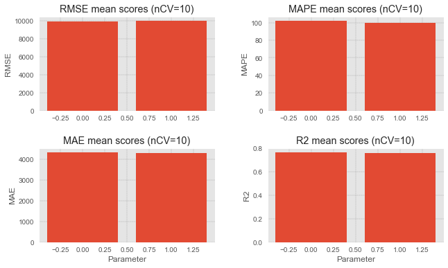

```
10 fold cross validation average scores of the best Estimator found by GridSearchCV

The average MAE for all cv folds is: 			 4291.4
The average MAE percentage (MAPE) for all cv folds is: 	 100.84
The average RMSE for all cv folds is: 			 9891.1
The average R2 for all cv folds is: 			 0.76303
Cross Validation Fold Mean Error Scores
           MAE        MAPE          RMSE        R2
0  4054.853637  102.336445   8693.011659  0.766774
1  4547.519760  104.832824  11082.619830  0.752768
2  3801.137221  100.477105   8084.223792  0.746955
3  4507.457955  108.532337  11084.087053  0.761351
4  4207.940868  104.539050   9468.479765  0.721471
5  4273.487715   93.824302   9592.838461  0.823995
6  4198.965610  100.780982   9255.290135  0.790276
7  4511.113667   94.311825  10398.555492  0.740476
8  4367.802637  102.895886   9564.537092  0.794119
9  4443.785087   95.884034  11687.776832  0.732100
Wall time: 21 s
```

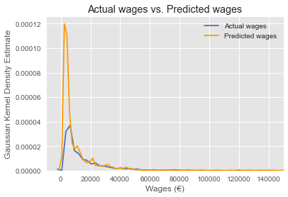

```python
%%time
from sklearn.ensemble import ExtraTreesRegressor

reg = ExtraTreesRegressor()
parameters = {'n_estimators': [ 350], 'max_leaf_nodes': [20],
              'min_impurity_decrease': [0],'max_depth':[15],
              'min_samples_split':[50,100],'min_samples_leaf':[3], 'max_features':['auto']
             }
m = evaluate_reg_model_performance('Extra Tree_LDA',parameters,reg,'RMSE',X_lda_train,y_reg_train,X_lda_test,y_reg_test,nCV=10, n_jobs=4)
model_reg_stats = model_reg_stats.append(m[0])
model_reg_yhat['Extra Tree_LDA'] = m[1].copy()
```

### 15. Multilayer Perceptron Regression_LDA

```
Best parameters set found:
{'activation': 'logistic', 'alpha': 0.001, 'batch_size': 'auto', 'hidden_layer_sizes': 50, 'learning_rate': 'adaptive', 'learning_rate_init': 0.001, 'max_iter': 2000, 'power_t': 0.5, 'random_state': 0, 'solver': 'sgd'}

Mean score summary of each gridsearch estimator executed
```

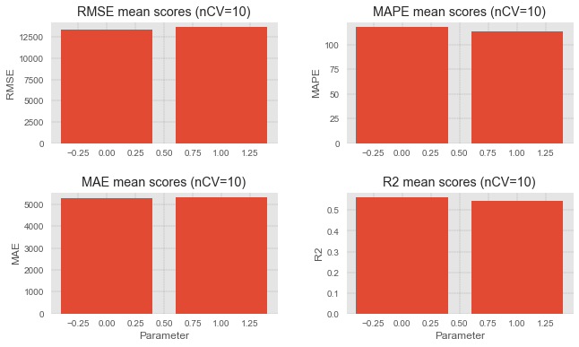

```
10 fold cross validation average scores of the best Estimator found by GridSearchCV

The average MAE for all cv folds is: 			 5276.0
The average MAE percentage (MAPE) for all cv folds is: 	 117.99
The average RMSE for all cv folds is: 			 1.3368e+04
The average R2 for all cv folds is: 			 0.56068
Cross Validation Fold Mean Error Scores
           MAE        MAPE          RMSE        R2
0  4864.549972  117.856404  10455.061107  0.662643
1  5628.891837  127.203190  15866.167184  0.493285
2  4914.459074  135.966416  10708.639514  0.555992
3  4786.965423  104.115578  12536.888387  0.694691
4  4904.450332  111.441524  12111.190091  0.544296
5  4596.212022   89.660035  10584.214685  0.785736
6  5639.811293  114.520229  15065.980101  0.444271
7  5344.374424  108.466927  12699.439905  0.612921
8  6136.565782  142.009893  15889.539033  0.431787
9  5943.492476  128.633109  17764.061466  0.381138
Wall time: 13min 59s
```

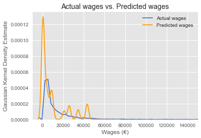

```python
%%time
from sklearn.neural_network import MLPRegressor

reg = MLPRegressor()
parameters = { 'activation':['logistic']
              ,'hidden_layer_sizes' : [50]
              ,'solver': ['sgd']
              ,'alpha': [0.001, .0001]
              ,'batch_size':['auto']
              ,'random_state': [0]
              ,'learning_rate': ['adaptive']
              ,'learning_rate_init':[0.001]
              ,'power_t':[0.5]
              ,'max_iter':[2000]
             }

m = evaluate_reg_model_performance('Perceptron_LDA',parameters,reg,'RMSE',X_lda_train,y_reg_train,X_lda_test,y_reg_test,nCV=10, n_jobs=4)
model_reg_stats = model_reg_stats.append(m[0])
model_reg_yhat['Perceptron_LDA'] = m[1].copy()
```

### 16. Support Vector Regression_LDA

```
Best parameters set found:
{'C': 0.1, 'epsilon': 0.1, 'gamma': 0.5, 'kernel': 'linear'}

Mean score summary of each gridsearch estimator executed
```

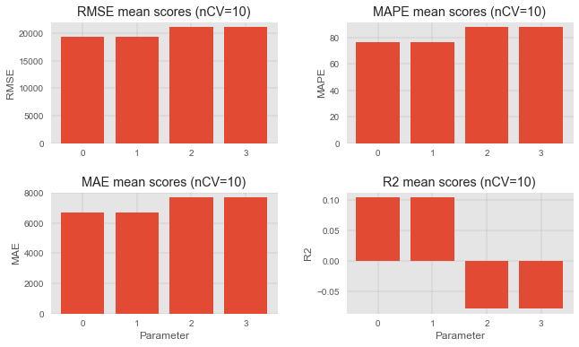

```
10 fold cross validation average scores of the best Estimator found by GridSearchCV

The average MAE for all cv folds is: 			 6723.1
The average MAE percentage (MAPE) for all cv folds is: 	 76.375
The average RMSE for all cv folds is: 			 1.9335e+04
The average R2 for all cv folds is: 			 0.10391
Cross Validation Fold Mean Error Scores
           MAE       MAPE          RMSE        R2
0  6206.949664  79.168097  16776.943154  0.131314
1  6750.243343  76.859958  21027.050373  0.110028
2  5921.831006  76.058390  15079.239271  0.119599
3  7325.961577  80.309786  21719.607921  0.083645
4  6389.130429  76.759021  16965.185669  0.105817
5  7296.803094  73.764294  21673.738232  0.101539
6  6473.602682  77.305822  19084.556308  0.108272
7  7082.734737  73.873730  19391.556003  0.097481
8  7006.346727  75.468449  20078.679125  0.092684
9  6777.373806  74.185201  21555.638258  0.088763
Wall time: 2min 41s
```

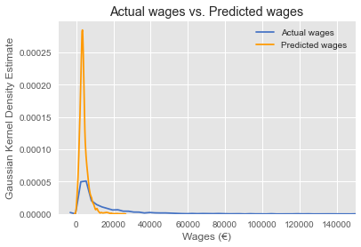

```python
%%time
from sklearn.svm import SVR
reg = SVR()

#Set up SVR parameters to test (WARNING: Creates 80 models!!!)
costs = [0.1, .01]
defGamma = 1 / X_lda_train.shape[1]  #This is the default value for the gamma parameter
gammas = [defGamma, 0.1]
kernels = ['linear']
epsilon = [0.1]
parameters = {'C': costs, 'gamma' : gammas, 'kernel': kernels, 'epsilon': epsilon}

m = evaluate_reg_model_performance('SVR_LDA',parameters,reg,'RMSE',X_lda_train,y_reg_train,X_lda_test,y_reg_test,nCV=10, n_jobs=4)
model_reg_stats = model_reg_stats.append(m[0])
model_reg_yhat['SVR_LDA'] = m[1].copy()
```

# 6. Modeling and Evaluation 4

### Classification Model Metrics Summary

```python
#model_clf_stats
#model_clf_stats
display(Markdown(model_clf_stats.sort_values(by = ["weighted_f1_score"], ascending = False).to_markdown()))
```

|  | model_name | scores | CM | time_refit | model_param | weighted_f1_score |
| --- | --- | --- | --- | --- | --- | --- |
| 0 | SVC SMOTE | [0.91932884 0.9151874 0.90936056 0.91389984 0.91952506] | precision recall f1-score support | 11.519 | {'C': 100, 'class_weight': None, 'gamma': 0.1, 'kernel': 'rbf'} | 0.92 |
|  |  |  | DEF 0.94 0.92 0.93 1473 |  |  |  |
|  |  |  | FWD 0.91 0.91 0.91 1473 |  |  |  |
|  |  |  | GK 1.00 1.00 1.00 1472 |  |  |  |
|  |  |  | MID 0.84 0.86 0.85 1472 |  |  |  |
|  |  |  | accuracy 0.92 5890 |  |  |  |
|  |  |  | macro avg 0.92 0.92 0.92 5890 |  |  |  |
|  |  |  | weighted avg 0.92 0.92 0.92 5890 |  |  |  |
| 0 | SVC | [0.86223685 0.84994418 0.86494892 0.85371808 0.86167741 0.86022477 | precision recall f1-score support | 3.84705 | {'C': 75, 'gamma': 0.01, 'kernel': 'rbf'} | 0.87 |
|  |  | 0.84636001 0.87461973 0.87728577 0.85926844] |  |  |  |  |
|  |  |  | DEF 0.94 0.95 0.94 1472 |  |  |  |
|  |  |  | FWD 0.83 0.82 0.83 917 |  |  |  |
|  |  |  | GK 1.00 1.00 1.00 407 |  |  |  |
|  |  |  | MID 0.72 0.71 0.72 859 |  |  |  |
|  |  |  | accuracy 0.87 3655 |  |  |  |
|  |  |  | macro avg 0.87 0.87 0.87 3655 |  |  |  |
|  |  |  | weighted avg 0.87 0.87 0.87 3655 |  |  |  |
| 0 | RF | [0.85214723 0.8508341 0.86376676 0.85803474 0.85570875 0.85553674 | precision recall f1-score support | 2.40148 | {'criterion': 'entropy', 'max_features': 'auto', 'min_samples_leaf': 5, 'n_estimators': 100, 'random_state': 0} | 0.86 |
|  |  | 0.84349265 0.87374838 0.86954166 0.84900966] |  |  |  |  |
|  |  |  | DEF 0.92 0.96 0.94 1472 |  |  |  |
|  |  |  | FWD 0.82 0.82 0.82 917 |  |  |  |
|  |  |  | GK 1.00 1.00 1.00 407 |  |  |  |
|  |  |  | MID 0.72 0.66 0.69 859 |  |  |  |
|  |  |  | accuracy 0.86 3655 |  |  |  |
|  |  |  | macro avg 0.86 0.86 0.86 3655 |  |  |  |
|  |  |  | weighted avg 0.86 0.86 0.86 3655 |  |  |  |
| 0 | XGBClassifier | [0.85591049 0.85255646 0.85774392 0.85345484 0.85765466 0.85041354 | precision recall f1-score support | 1.62978 | {'booster': 'gbtree', 'n_estimators': 50, 'random_state': 0} | 0.86 |
|  |  | 0.84069863 0.86915439 0.86335022 0.8577578 ] |  |  |  |  |
|  |  |  | DEF 0.93 0.95 0.94 1472 |  |  |  |
|  |  |  | FWD 0.81 0.81 0.81 917 |  |  |  |
|  |  |  | GK 1.00 1.00 1.00 407 |  |  |  |
|  |  |  | MID 0.71 0.68 0.69 859 |  |  |  |
|  |  |  | accuracy 0.86 3655 |  |  |  |
|  |  |  | macro avg 0.86 0.86 0.86 3655 |  |  |  |
|  |  |  | weighted avg 0.86 0.86 0.86 3655 |  |  |  |
| 0 | KNN | [0.83658626 0.83465821 0.84552477 0.84440995 0.84144104 0.83302984 | precision recall f1-score support | 0.110563 | {'algorithm': 'auto', 'n_neighbors': 97} | 0.84 |
|  |  | 0.84036907 0.84863997 0.85161176 0.83385161] |  |  |  |  |
|  |  |  | DEF 0.90 0.95 0.92 1472 |  |  |  |
|  |  |  | FWD 0.82 0.78 0.80 917 |  |  |  |
|  |  |  | GK 1.00 1.00 1.00 407 |  |  |  |
|  |  |  | MID 0.67 0.65 0.66 859 |  |  |  |
|  |  |  | accuracy 0.84 3655 |  |  |  |
|  |  |  | macro avg 0.85 0.84 0.85 3655 |  |  |  |
|  |  |  | weighted avg 0.84 0.84 0.84 3655 |  |  |  |
| 0 | AdaBoost | [0.79482917 0.82302397 0.79987692 0.79493517 0.7974642 0.79822841 | precision recall f1-score support | 4.57056 | {'algorithm': 'SAMME', 'n_estimators': 150, 'random_state': 0} | 0.81 |
|  |  | 0.78599852 0.81816246 0.80755594 0.79740725] |  |  |  |  |
|  |  |  | DEF 0.91 0.95 0.93 1472 |  |  |  |
|  |  |  | FWD 0.70 0.91 0.79 917 |  |  |  |
|  |  |  | GK 1.00 1.00 1.00 407 |  |  |  |
|  |  |  | MID 0.72 0.43 0.54 859 |  |  |  |
|  |  |  | accuracy 0.83 3655 |  |  |  |
|  |  |  | macro avg 0.83 0.82 0.82 3655 |  |  |  |
|  |  |  | weighted avg 0.82 0.83 0.81 3655 |  |  |  |
| 0 | Decisiontree | [0.81129379 0.81260938 0.80505377 0.80426119 0.81089187 0.81180071 | precision recall f1-score support | 0.0422578 | {'criterion': 'gini', 'min_samples_leaf': 10, 'random_state': 0, 'splitter': 'random'} | 0.81 |
|  |  | 0.809215 0.82123329 0.83656617 0.81247633] |  |  |  |  |
|  |  |  | DEF 0.90 0.93 0.91 1472 |  |  |  |
|  |  |  | FWD 0.77 0.78 0.77 917 |  |  |  |
|  |  |  | GK 1.00 0.99 0.99 407 |  |  |  |
|  |  |  | MID 0.62 0.59 0.60 859 |  |  |  |
|  |  |  | accuracy 0.82 3655 |  |  |  |
|  |  |  | macro avg 0.82 0.82 0.82 3655 |  |  |  |
|  |  |  | weighted avg 0.81 0.82 0.81 3655 |  |  |  |
| 0 | Extratree | [0.79369748 0.79947339 0.80280316 0.80499467 0.80875171 0.8114768 | precision recall f1-score support | 0.0458763 | {'criterion': 'gini', 'max_features': 'auto', 'min_samples_leaf': 10, 'random_state': 0} | 0.81 |
|  |  | 0.80085688 0.83148955 0.80807801 0.80035728] |  |  |  |  |
|  |  |  | DEF 0.90 0.91 0.91 1472 |  |  |  |
|  |  |  | FWD 0.76 0.77 0.76 917 |  |  |  |
|  |  |  | GK 1.00 1.00 1.00 407 |  |  |  |
|  |  |  | MID 0.60 0.58 0.59 859 |  |  |  |
|  |  |  | accuracy 0.81 3655 |  |  |  |
|  |  |  | macro avg 0.81 0.81 0.81 3655 |  |  |  |
|  |  |  | weighted avg 0.81 0.81 0.81 3655 |  |  |  |
| 0 | GNB | [0.78084951 0.78533087 0.79123654 0.79942277 0.78202675 0.78251334 | precision recall f1-score support | 0.0229514 | {'priors': None, 'var_smoothing': 1e-05} | 0.8 |
|  |  | 0.79660223 0.7974527 0.78963785 0.78565489] |  |  |  |  |
|  |  |  | DEF 0.93 0.82 0.87 1472 |  |  |  |
|  |  |  | FWD 0.78 0.76 0.77 917 |  |  |  |
|  |  |  | GK 1.00 1.00 1.00 407 |  |  |  |
|  |  |  | MID 0.54 0.67 0.60 859 |  |  |  |
|  |  |  | accuracy 0.79 3655 |  |  |  |
|  |  |  | macro avg 0.81 0.81 0.81 3655 |  |  |  |
|  |  |  | weighted avg 0.81 0.79 0.80 3655 |  |  |  |

```python
import altair as alt
def plot_alt_test(df, attr,best_model):
    alt1 = alt.Chart(df).mark_bar().encode(
        y = alt.Y('model_name',
                  title = 'Model Name',
                  sort = alt.EncodingSortField(field=attr, order='ascending')
                 ),
        x = alt.X(attr,
                  title = attr+' scores of each model'
                 ),
        color = alt.condition(
            alt.datum.model_name == best_model,
            alt.value('orange'),
            alt.value('steelblue'))
        ).properties(
            title='Best Model (Orange) With '+attr+' Scores',
            width = 300,
            height = 300
        )
    return alt1
plot_alt_test(model_clf_stats, 'weighted_f1_score','SVC SMOTE')
```

[interactive chart not shown]

#### ROC Curve of top two models

```python
import warnings
warnings.filterwarnings('ignore')
from yellowbrick.classifier import ROCAUC
def plot_roc(est, X_test, y_test, X_train, y_train):
    visualizer = ROCAUC(est, classes=["DEF", "FWD", "MID","GK"])
    visualizer.fit(X_train, y_train)        # Fit the training data to the visualizer
    visualizer.score(X_test, y_test)        # Evaluate the model on the test data
    visualizer.show()
```

[figure not shown]

```python
#C': 100, 'class_weight': None, 'gamma': 0.1, 'kernel': 'rbf'
from sklearn.svm import SVC
SVC = SVC(C=100,  gamma=0.1, kernel='rbf' ,probability=True)
plot_roc(SVC, X_clf_sm_test, y_clf_sm_test, X_clf_sm_train, y_clf_sm_train)
```

[figure not shown]

```python
#'C': 75, 'gamma': 0.01, 'kernel': 'rbf
from sklearn.svm import SVC
SVC = SVC(C=75,  gamma=0.01, kernel='rbf' ,probability=True)
plot_roc(SVC, X_clf_test, y_clf_test, X_clf_train, y_clf_train)
```

Looking at ROC curves and f1 scores and confusion matrices, our best classication model is SVC SMOTE with macro-average AUC 0.99.

Two metrices (AUC, f1 score) have been used to select the best classification model. The best model is SVM SMOTE model according to f1 score and AUC.

### Regression Model Metrics Summary

```python
display(Markdown(model_reg_stats.sort_values(by = ["RMSE"]).to_markdown()))
```

|  | model_name | RMSE | MAPE | MAE | R2 |
| --- | --- | --- | --- | --- | --- |
| 0 | ExtraTree | 9437.1 | 97.8148 | 4224.62 | 0.7878 |
| 0 | Random Forest | 9538.33 | 91.2627 | 4197.22 | 0.778992 |
| 0 | Random Forest_LDA | 9892.61 | 89.6348 | 4214.96 | 0.767262 |
| 0 | Extra Tree_LDA | 9892.74 | 102.608 | 4308.83 | 0.767326 |
| 0 | Ridge Reg_LDA | 9893.81 | 99.1239 | 4375.74 | 0.762421 |
| 0 | Lasso Reg_LDA | 9894.07 | 99.0923 | 4376.17 | 0.762391 |
| 0 | Linear Reg_LDA | 9894.07 | 99.0913 | 4376.16 | 0.762391 |
| 0 | Ridge Reg | 9918.46 | 99.8868 | 4415.5 | 0.761219 |
| 0 | Lasso Reg | 9918.95 | 99.8963 | 4416.23 | 0.761179 |
| 0 | Linear Reg | 9919 | 99.9211 | 4416.63 | 0.761177 |
| 0 | Perceptron_LDA | 13314.8 | 107.517 | 5132.31 | 0.575411 |
| 0 | MLPerceptron | 15448.4 | 264.177 | 7950.32 | 0.429008 |
| 0 | Elastic Net Reg | 16299.2 | 217.555 | 7412.7 | 0.365143 |
| 0 | SVR | 19777.2 | 83.0406 | 6882.5 | 0.0623874 |
| 0 | SVR_LDA | 19925.1 | 76.4976 | 6923.26 | 0.0577921 |
| 0 | Elastic Net Reg_LDA | 20374.1 | 342.38 | 10085.4 | 0.00384517 |

```python
reg_models = pd.concat([model_reg_stats, model_reg_lda_stats])
alt.hconcat(plot_alt_test(reg_models, 'RMSE','ExtraTree'), plot_alt_test(reg_models, 'MAPE','SVR_LDA'))
alt.hconcat(plot_alt_test(reg_models, 'MAE','Random Forest'), plot_alt_test(reg_models, 'R2','ExtraTree'))
```

[interactive chart not shown]

Four metrices (RMSE, MAPE, MAE, R2) have been used to select the best regression model.

- The best model is ExtraTree model according to RMSE and R2
- The best model is Random Forest model according to MAE
- The best model is SVR_LDA model according to MAPE

⏫ Table of Contents

# 7. Modeling and Evaluation 5

### Classification models

```python
from scipy import stats
from math import sqrt
from scipy.stats import t
def compare_models(model_name1, model_name2, acc1, acc2):

    # Run independent t-test
    ind_t_test = stats.ttest_ind(acc1,acc2)
    print(ind_t_test)
    # Calculate the mean difference and 95% confidence interval
    N1 = 3
    N2 = 3
    df = (N1 + N2 - 2)
    std1 = acc1.std()
    std2 = acc2.std()
    std_N1N2 = sqrt( ((N1 - 1)*(std1)**2 + (N2 - 1)*(std2)**2) / df)
    diff_mean = acc1.mean() - acc2.mean()
    MoE = t.ppf(0.975, df) * std_N1N2 * sqrt(1/N1 + 1/N2)


    print('t-test for {}-{}: \n\tt-statistic = {:4.3f}\n\tp-value = {:4.3f}'.format(model_name1, model_name2,ind_t_test[0],ind_t_test[1]))
    print ('\nThe difference between groups is {:3.5f} [{:3.5f} to {:3.5f}] (mean [95% CI])'.format(diff_mean, diff_mean - MoE, diff_mean + MoE))
```

#### T-stat of SVC Vs XGBC

```python
compare_models(model_clf_stats.iloc[6].model_name,model_clf_stats.iloc[7].model_name,
               model_clf_stats.iloc[6].scores.flatten(), model_clf_stats.iloc[7].scores.flatten())
```

```
Ttest_indResult(statistic=-1.317025613844641, pvalue=0.20435145687620287)
t-test for XGBClassifier-SVC:
	t-statistic = -1.317
	p-value = 0.204

The difference between groups is -0.00516 [-0.02400 to 0.01368] (mean [95% CI])
```

#### T-stat of RF vs XGBC

```python
compare_models(model_clf_stats.iloc[2].model_name,model_clf_stats.iloc[6].model_name,
               model_clf_stats.iloc[2].scores.flatten(), model_clf_stats.iloc[6].scores.flatten())
```

```
Ttest_indResult(statistic=0.3433274172226993, pvalue=0.73532957262576)
t-test for RF-XGBClassifier:
	t-statistic = 0.343
	p-value = 0.735

The difference between groups is 0.00131 [-0.01707 to 0.01970] (mean [95% CI])
```

We can see the p-value of t-test for Model 2 (SVC) -Model 3 (XGBC) is 0.204 and for Model 3 (XGBC) -Model 4 (RF) is 0.735, larger than 0.05, we cannot reject the null hypothesis and may conclude that the performance of the two algorithms (Model 2-Model 3 or Model 3-Model 4) are not significantly different. Then there are no significant difference between Model 2-Model 3-Model 4 mathematically with 95% confidence.

⏫ Table of Contents

# 8. Modeling and Evaluation 6

## A. Position Classification Model

The feature importances can be calculated using the Mean decrease in the gini index. Essentially, every time a feature is tested for splitting, the decrease in the gini (or entropy) is saved. The importance of the feature can then be approximated by taking the mean decrease in the gini for all the nodes where the feature is tested (usually the feature is tested at every node): $$ Imp_{A} = \frac{1}{|T|}\sum_{t \in T} gini_A(p_t) - gini_A(t) $$ where $|T|$ is the total number of nodes in the tree, $T$ is the set of all nodes, $gini_A(t)$ is the gini for the $A^{th}$ attribute at node $t$, and $gini_A(p_t)$ is the gini for the $A^{th}$ attribute at the **parent** node for $t$.

In this way, we have the mean decrease in the gini for attribute $A$. We can make a vector of these importance for all attributes in the dataset: $[Imp_1, Imp_2, ... Imp_{A_{tot}}]$.

`scikit-learn` computes this value for you and it is stored inside the tree object as `dt_clf.feature_importances_`. For the current dataset, there are feature vectors of size 31 skills. Therefore, we can look at the importances as a bar graph with 31 corresponding instances.

### Feature Importances from Decision Tree

```python
dt_clf = DecisionTreeClassifier(criterion='entropy', max_depth=None,
                                min_samples_split=100, min_samples_leaf=1,
                                max_leaf_nodes=None)

# train the decision tree algorithm
dt_clf.fit(X_clf_train,y_clf_train)
yhat = dt_clf.predict(X_clf_test)
print ('accuracy:', mt.accuracy_score(y_clf_test,yhat))

# get the importances
imp = dt_clf.feature_importances_
```

```
DecisionTreeClassifier(criterion='entropy', min_samples_split=100)
```

```
accuracy: 0.8309165526675787
```

```python
l=df_mental_attr.append(df_attacking_attr).append(df_skill_attr).append(df_movement_attr).append(df_power_attr).append(df_defending_attr)
l=l.append(pd.Series(['height_cm','weight_kg']))
# Below is the important of each attributes.
for im, name in zip(imp,l):
    print(name, 'has important of', im)
```

```
mentality_aggression has important of 0.0003213345692660882
mentality_interceptions has important of 0.00547837219092088
mentality_positioning has important of 0.006831423701543076
mentality_vision has important of 0.03669972207232344
mentality_penalties has important of 0.0018022253778316442
mentality_composure has important of 0.003182463725219133
attacking_crossing has important of 0.018449554923250636
attacking_finishing has important of 0.07915076701634502
attacking_heading_accuracy has important of 0.03281227929466647
attacking_short_passing has important of 0.0024877435214237078
attacking_volleys has important of 0.003723726154738075
skill_dribbling has important of 0.008407286303602025
skill_curve has important of 0.0005754116723223362
skill_fk_accuracy has important of 0.0007627844684750848
skill_long_passing has important of 0.0192584519951386
skill_ball_control has important of 0.0010010856591245937
movement_acceleration has important of 0.002513880563133581
movement_sprint_speed has important of 0.0031471996658397517
movement_agility has important of 0.001604551877933778
movement_reactions has important of 0.0005848114524870838
movement_balance has important of 0.0007827510129853345
power_shot_power has important of 0.0024201413021188284
power_jumping has important of 0.001410517338382835
power_stamina has important of 0.0016533464098107988
power_strength has important of 0.001449865681392109
power_long_shots has important of 0.24590448047270289
defending_marking has important of 0.04701490598199163
defending_standing_tackle has important of 0.006143231178755774
defending_sliding_tackle has important of 0.4631169355748579
height_cm has important of 0.0005853753876100114
weight_kg has important of 0.0007233734538069199
```

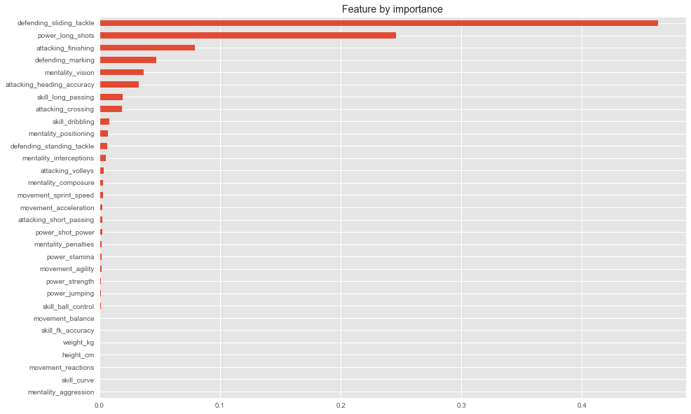

```python
important = pd.Series(imp,index=l)
sort_important = important.sort_values(0,ascending=True)
from matplotlib import pyplot as plt
%matplotlib inline
a =plt.style.use('ggplot')
a =plt.figure(figsize=(15,10))
a =sort_important.plot(kind='barh',title ='Feature by importance')
plt.show()
```

### Feature Importances from Random Forest

```python
from sklearn.ensemble import RandomForestClassifier

rf_clf = RandomForestClassifier(bootstrap='True', criterion='gini', max_features= 'auto', min_samples_leaf=5, n_estimators= 100, random_state= 0)
rf_clf.fit(X_clf_train,y_clf_train)
yhat = rf_clf.predict(X_clf_test)
print ('accuracy:', mt.accuracy_score(y_clf_test,yhat))

# get the importances
imp = rf_clf.feature_importances_

l=df_mental_attr.append(df_attacking_attr).append(df_skill_attr).append(df_movement_attr).append(df_power_attr).append(df_defending_attr)
l=l.append(pd.Series(['height_cm','weight_kg']))

# Below is the important of each attributes.
for im, name in zip(imp,l):
    print(name, 'has important of', im)
```

```
RandomForestClassifier(bootstrap='True', min_samples_leaf=5, random_state=0)
```

```
accuracy: 0.8626538987688098
mentality_aggression has important of 0.012062565913264501
mentality_interceptions has important of 0.10044113537803331
mentality_positioning has important of 0.07536400657948622
mentality_vision has important of 0.03302419866985681
mentality_penalties has important of 0.022574171679288806
mentality_composure has important of 0.006905851115629001
attacking_crossing has important of 0.0349312228377633
attacking_finishing has important of 0.08636606771761694
attacking_heading_accuracy has important of 0.042344314299319334
attacking_short_passing has important of 0.014343732397213193
attacking_volleys has important of 0.04036991597245138
skill_dribbling has important of 0.03255538007602792
skill_curve has important of 0.017374800629789737
skill_fk_accuracy has important of 0.018049840480128213
skill_long_passing has important of 0.020561293232529535
skill_ball_control has important of 0.035029269837809504
movement_acceleration has important of 0.008929023636857051
movement_sprint_speed has important of 0.008660963749489945
movement_agility has important of 0.006944893229925949
movement_reactions has important of 0.006433543342724757
movement_balance has important of 0.007433834794282744
power_shot_power has important of 0.010911103845402116
power_jumping has important of 0.00816703184508195
power_stamina has important of 0.009421511191583512
power_strength has important of 0.01027434931672667
power_long_shots has important of 0.03016201650827044
defending_marking has important of 0.06963327709168729
defending_standing_tackle has important of 0.09420259226179142
defending_sliding_tackle has important of 0.1252404850411933
height_cm has important of 0.00566451840114058
weight_kg has important of 0.00562308892763469
```

[figure not shown]

```python
sort_important = important.sort_values(0,ascending=True)
from matplotlib import pyplot as plt
%matplotlib inline
a =plt.style.use('ggplot')
a =plt.figure(figsize=(15,10))
a =sort_important.plot(kind='barh',title ='Feature by importance')
plt.show()
```

## B. Salary Estimate Regression Model

### Feature Importance from Random Forest Model

https://www.scikit-yb.org/en/latest/api/model_selection/importances.html The feature engineering process involves selecting the minimum required features to produce a valid model because the more features a model contains, the more complex it is (and the more sparse the data), therefore the more sensitive the model is to errors due to variance. A common approach to eliminating features is to describe their relative importance to a model, then eliminate weak features or combinations of features and re-evalute to see if the model fairs better during cross-validation.  
Many model forms describe the underlying impact of features relative to each other. In scikit-learn, Decision Tree models and ensembles of trees such as Random Forest, Gradient Boosting, and Ada Boost provide a feature*importances* attribute when fitted. The Yellowbrick FeatureImportances visualizer utilizes this attribute to rank and plot relative importances.

The detail positions are the least important features to the model. Surprisingly, the international reputation is not very important to the model. The rest of the features are not with very close importance value.

[output not shown]

[output cut: 32 more lines]

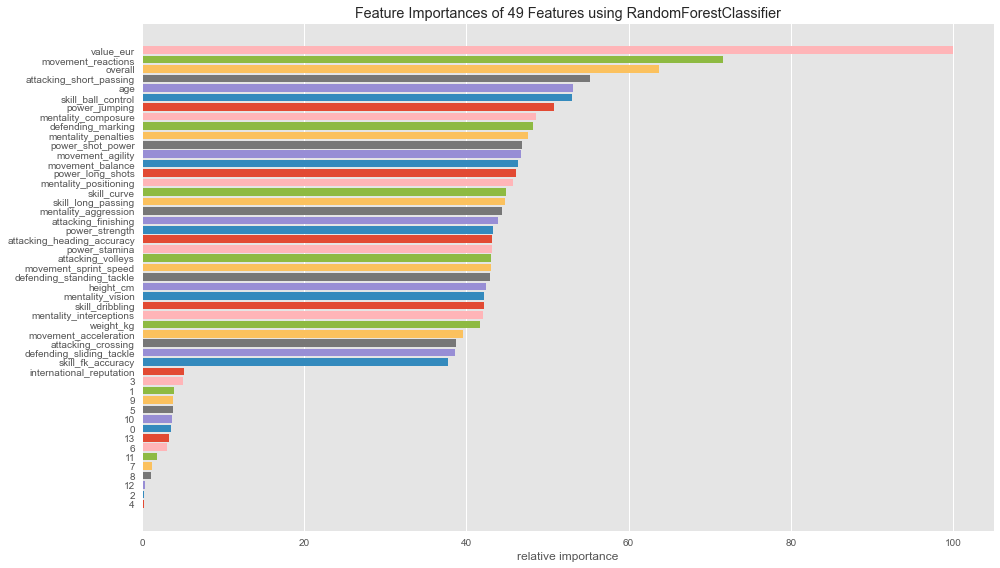

```python
from sklearn.ensemble import RandomForestClassifier as rfc
from yellowbrick.model_selection import FeatureImportances as fimp
import matplotlib.pyplot as plt

l=df_mental_attr.append(df_attacking_attr).append(df_skill_attr).append(df_movement_attr).append(df_power_attr).append(df_defending_attr)
l=l.append(pd.Series(['age','international_reputation','value_eur','overall','height_cm','weight_kg']))
l=l.append(pd.Series(['0','1','2','3','4','5','6','7','8','9','10','11','12','13']))

plt.figure(figsize=(14,8))
model = rfc(n_estimators=10,random_state=45)

viz = fimp(model,labels=l)
viz.fit(X_reg_test, y_reg_test)
viz.show()
```

```python
from sklearn.preprocessing import OneHotEncoder

# we will create the encoder and drop the first column
enc = OneHotEncoder(handle_unknown='error', drop='first').fit(df_players[['preferred_position']])
df_players.shape
enc.categories_
X = enc.transform(df_players[['preferred_position']]).toarray()
X.shape
#Check the categories
enc.inverse_transform([[0, 0, 0, 0, 0,0,0,0,0,0,0,0,0,0]])

## Add back to df
p = pd.DataFrame(X)
p.shape
## We will use this dataframe later to add it to the regression classification set

#create a list of columns that we will include in our final dataset for our task 2

l=df_mental_attr.append(df_attacking_attr).append(df_skill_attr).append(df_movement_attr).append(df_power_attr).append(df_defending_attr)
l=l.append(pd.Series(['age','international_reputation','overall','height_cm','weight_kg',
                     ]))

df_players_reg = df_players[l].copy()
df_players_reg.shape
# Adding the one hot encoded position dataframe generated earlier
df_players_reg = pd.concat([df_players_reg, p], axis=1)
df_players_reg.shape

players_reg_X = df_players_reg.values
players_reg_y = df_players['wage_eur'].values

##Scale the transformed data
scl_obj = StandardScaler()
scl_obj.fit(players_reg_X)
X_players_reg_scaled = scl_obj.transform(players_reg_X)
players_reg_X.shape
players_reg_y.shape
X_players_reg_scaled.shape

X_reg_train, X_reg_test, y_reg_train, y_reg_test = train_test_split(X_players_reg_scaled, players_reg_y,
                                                    test_size=0.2, stratify=y_binned, random_state= 45)
```

```
(18275, 88)
```

```
[array(['CAM', 'CB', 'CDM', 'CF', 'CM', 'GK', 'LB', 'LM', 'LW', 'LWB',
        'RB', 'RM', 'RW', 'RWB', 'ST'], dtype=object)]
```

```
(18275, 14)
```

```
array([['CAM']], dtype=object)
```

```
(18275, 14)
```

```
(18275, 34)
```

```
(18275, 48)
```

```
StandardScaler()
```

```
(18275, 48)
```

```
(18275,)
```

```
(18275, 48)
```

[output not shown]

[output cut: 31 more lines]

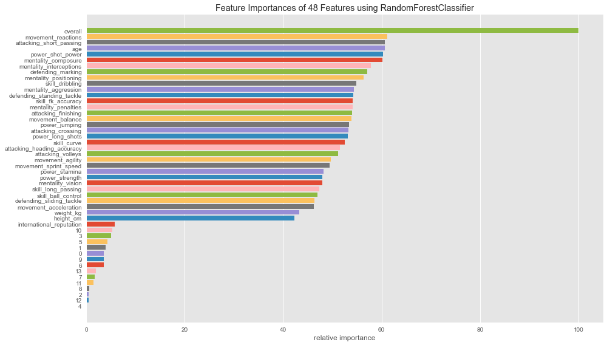

```python
from sklearn.ensemble import RandomForestClassifier as rfc
from yellowbrick.model_selection import FeatureImportances as fimp
import matplotlib.pyplot as plt

l=df_mental_attr.append(df_attacking_attr).append(df_skill_attr).append(df_movement_attr).append(df_power_attr).append(df_defending_attr)
l=l.append(pd.Series(['age','international_reputation','overall','height_cm','weight_kg']))
l=l.append(pd.Series(['0','1','2','3','4','5','6','7','8','9','10','11','12','13']))

plt.figure(figsize=(14,8))
model = rfc(n_estimators=10,random_state=45)

viz = fimp(model,labels=l)
viz.fit(X_reg_test, y_reg_test)
viz.show()
```

⏫ Table of Contents

# 9. Deployment

Soccer clubs will be interested in our analyses. The Random Forest or Extra Tree model provide estimate of soccer players salary predictions. Clubs can offer salary when acquiring players base on the predictions. Also, the predictions can be a good reference when negotiating salary. The position classification task will provide good insight when coach prepare a team training strategy. Coach can decide the position of a player should play base on the prediction. And when switching positions of a player, coach can prepare a better strategy of what skills should the player focus on.

When a club is considering to trade players, we can deploy our models. For trading players, we can select players who the estimate salary are in the range of the budget. When there is a player the club wants to acquire, depending on how much desire the club wants to player, club can take the estimate salary as a reference. If the club thinks the player will fit well, it may offer salary that is higher than the estimate salary from our model. Also, when acquiring younger and newer players, the estimate salary can be a good reference because our model is driven by players' skills. We should collect the players' contract information so we can find out which players can be traded. Also, we can scrub players related news data so we can better understand players desires or preference.

The model need to be updated before trading windows or when club has a plan to trade a player. The running time for the deployment is not significant because the size of the data is small.

⏫ Table of Contents

# 10. Exceptional Work

```python
#The n_jobs parameter tells Scikit-Learn the number of CPU cores to use for training and predictions
#(–1 tells Scikit-Learn to use all available cores):
from sklearn.ensemble import RandomForestClassifier, VotingClassifier
from sklearn.svm import SVC
from sklearn.naive_bayes import GaussianNB
SVC_clf = SVC(C=100,  gamma=0.1, kernel='rbf' ,probability=True)

rnd_clf = RandomForestClassifier(criterion  = 'gini', max_features = 'auto', min_samples_leaf = 5,
                                 n_estimators = 100, random_state= 0)

gnb_clf = GaussianNB(priors  = None, var_smoothing = 0.001)


voting_clf = VotingClassifier(
    estimators=[('SVC', SVC_clf),  ('rnd', rnd_clf), ('NB', gnb_clf)],
    voting='soft', n_jobs=-1)
voting_clf.fit(X_clf_train, y_clf_train)
y_pred = voting_clf.predict(X_clf_test)
```

```
VotingClassifier(estimators=[('SVC', SVC(C=100, gamma=0.1, probability=True)),
                             ('rnd',
                              RandomForestClassifier(min_samples_leaf=5,
                                                     random_state=0)),
                             ('NB', GaussianNB(var_smoothing=0.001))],
                 n_jobs=-1, voting='soft')
```

```
              precision    recall  f1-score   support

         DEF       0.93      0.92      0.92      1472
         FWD       0.79      0.78      0.78       917
          GK       1.00      1.00      1.00       407
         MID       0.64      0.67      0.65       859

    accuracy                           0.83      3655
   macro avg       0.84      0.84      0.84      3655
weighted avg       0.84      0.83      0.83      3655
```

```
<sklearn.metrics._plot.confusion_matrix.ConfusionMatrixDisplay at 0x27ebfb12248>
```

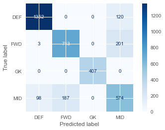

```python
s = classification_report(y_clf_test, y_pred, target_names=['DEF', 'FWD', 'GK','MID'])
print(s)
plot_confusion_matrix(voting_clf, X_clf_test,y_clf_test,cmap=plt.cm.Blues,values_format='d')
```

⏫ Table of Contents